# Introduction to Spatial Data: QERM 597

Brielle K Thompson

5/12/2022

## Introduction to Spatial Data

Spatial data can be described by three data models:

1. *Vector data*: represents spatial information with points, lines, polygons
2. *Raster data*: represents surfaces
3. *Spatial data cubes*: represents spatial information from repeated measures

### Vector data

- The vector data model represents the world as a set of spatial geometries with non-spatial attributes
- Three types of geometries:
  - *Points*: represented by a pair of coordinates within a coordinate reference system (CRS)
  - *Lines*: represented by several points connected by a straight line
  - *Polygons*: represented by a set points connected by a straight line (a closed object). Polygons can have holes!
- Non-spatial attributes associated with the geometries include additional information (e.g., identification number, some characteristic)
- File formats for vector data:
  - Simple files: text file (.csv) or as a spreadsheet (.xls or .xlsx)
    - These files are not easy for complex objects
    - These files are not suitable for storing information on the coordinate system
  - Typical files: shape file format (.shp) is most widely supported and used
    - shp files require storing several files
    - Attribute names are limited to ten characters
    - Stores up to 255 attributes and files up to 2GB
  - New types of files:
    - OGC GeoPackage (.gpkg), GeoJSON (.geojson), GPX (.gpx), and KML (.kml).

#### sf package and vector data

```r
library(sf)
```

- GDAL: used for reading, writing and manipulating a wide range of geographic data formats [reference](https://geocompr.robinlovelace.net/read-write.html#read-write)
- PROJ: a library for coordinate system transformations [referemce](https://geocompr.robinlovelace.net/reproj-geo-data.html#reproj-geo-data)
- GEOS, a planar geometry engine for operations such as calculating buffers and centroids on data with a projected CRS [reference](https://geocompr.robinlovelace.net/geometric-operations.html#geometric-operations)
- S2: a spherical geometry engine written in C++ developed by Google, via the s2 package [reference](https://geocompr.robinlovelace.net/spatial-class.html#s2) [reference](https://geocompr.robinlovelace.net/reproj-geo-data.html#reproj-geo-data)

#### Quick example:

We will use an example from a pre-existing spatial data source. World is an ‘sf data frame’ containing spatial and attribute columns

```r
class(world)
```

```
## [1] "sf"         "tbl_df"     "tbl"        "data.frame"
```

Here are the spatial attributes:

```r
names(world) #attribute columns
```

```
##  [1] "iso_a2"    "name_long" "continent" "region_un" "subregion" "type"
##  [7] "area_km2"  "pop"       "lifeExp"   "gdpPercap" "geom"
```

Lets make a quick plot: sf objects make a map for each variable in the data frame

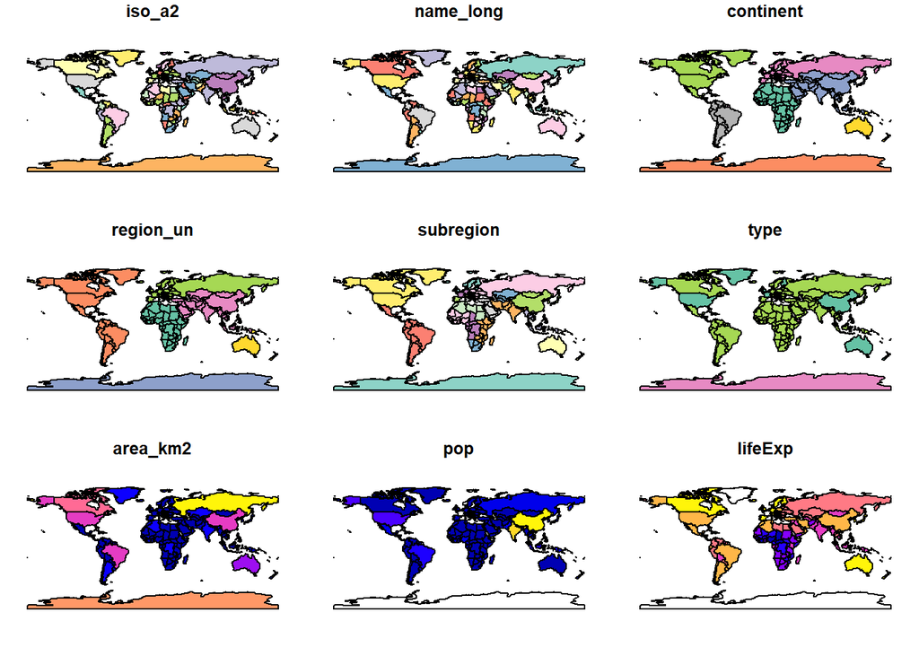

```r
plot(world)
```

We can take a look at the summary information of the sf object. For example, lets look at the summary for the attribute for population:

```r
summary(world["pop"])
```

```
##       pop                       geom
##  Min.   :5.630e+04   MULTIPOLYGON :177
##  1st Qu.:3.755e+06   epsg:4326    :  0
##  Median :1.040e+07   +proj=long...:  0
##  Mean   :4.282e+07
##  3rd Qu.:3.075e+07
##  Max.   :1.364e+09
##  NA's   :10
```

#### Manipulating sf objects:

We can easily subset sf objects. Lets select the first two countries and its first 3 attributes

```r
#selecting the first two countries and its first 3 attributes
mini_world <- world[1:2, 1:3]
mini_world
```

```
## Simple feature collection with 2 features and 3 fields
## Geometry type: MULTIPOLYGON
## Dimension:     XY
## Bounding box:  xmin: -180 ymin: -18.28799 xmax: 180 ymax: -0.95
## Geodetic CRS:  WGS 84
## # A tibble: 2 × 4
##   iso_a2 name_long continent                                                geom
##   <chr>  <chr>     <chr>                                      <MULTIPOLYGON [°]>
## 1 FJ     Fiji      Oceania   (((-180 -16.55522, -179.9174 -16.50178, -179.7933 …
## 2 TZ     Tanzania  Africa    (((33.90371 -0.95, 31.86617 -1.02736, 30.76986 -1.…
```

#### Using ‘our own’ data:

Lets load our data. We will be using the honey data set that describes honey production and prices across U.S. states.

```r
# load the csv file for honey production in the us
honey_csv <- read_csv("honeyproduction.csv")
# load the xlsx file for abbreviations of the us states
abbrev <- read_xlsx("abbrev.xlsx")
# load honey shapefile
honey_sf <- read_sf("honey.shp") #honey.shx is needed in your working directory
```

Lets plot the data:

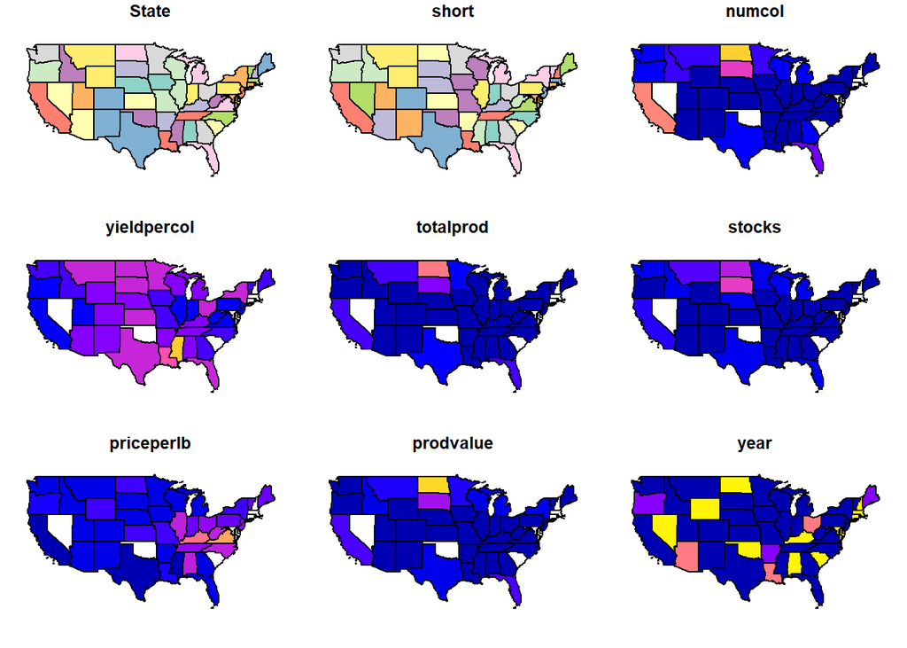

```r
plot(honey0912)
```

Lets plot just price per lb:

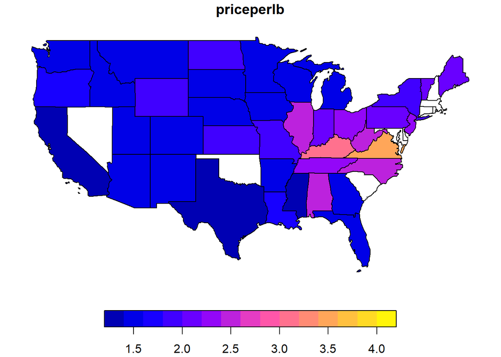

```r
plot(honey0912["priceperlb"])
```

There are many ways to modify maps with sf’s plot() method. Base R plotting methods work with sf objects.

For example, the figure below overlayes circles, whose diameters (set with cex =) represent honey prices in each state, on a map of the U.S.

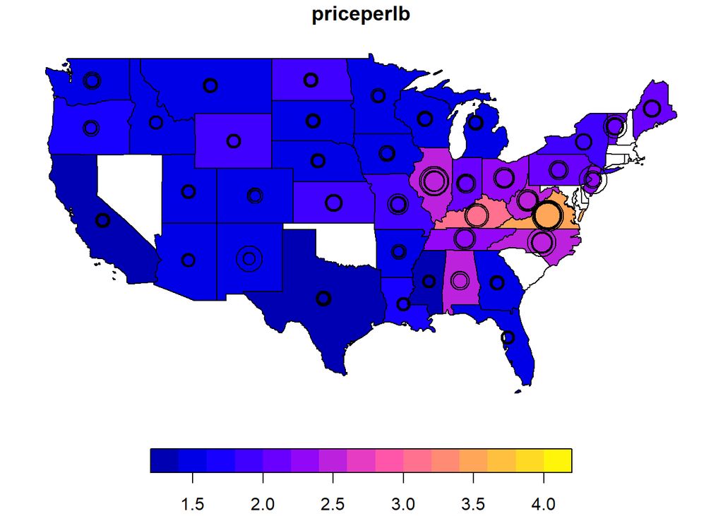

```r
plot(honey0912["priceperlb"], reset = FALSE)
cex = honey0912$priceperlb
price_cents = st_centroid(honey0912, of_largest = TRUE)
plot(st_geometry(price_cents), add = TRUE, cex = cex)
```

- Exercise: do this for a different attribute in the honey dataset

The sf’s plot method also has arguments specific to geographic data. We will use the expandBB, for example, to plot an sf object in context. This argument takes a numeric vector of length four that expands the bounding box of the plot relative to zero in the following order: bottom, left, top, right. This is used to plot Washington in the context of the U.S.

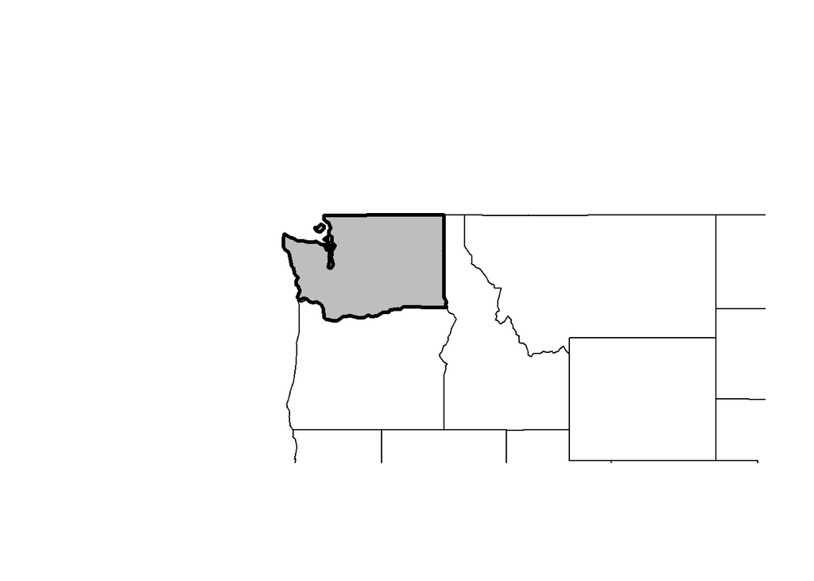

```r
washington = honey0912[honey0912$State == "Washington", ]
plot(st_geometry(washington), expandBB = c(1, 1, 0.8, 1.8), col = "gray", lwd = 3)
plot(honey0912[0], add = TRUE)
```

### Raster data

- The raster data model represents the world using a continuous grid of cells, where each cell has a single associated value
- We can often distinguish continuous and categorical rasters
  - Continuous rasters: values vary progressively (e.g., elevation or precipitation)
  - Categorical rasters: uses integer values to represent classes (e.g., land cover or soil types)
  - Raster data can also contain cells for which we do not know the value
- Contrary to spatial vector data, a basic raster data stores just one attribute
  - But we can stack multiple rasters together (raster layers or temporal rasters)
- File formats for raster data:
  - GeoTIFF format (.tif or .tiff)
  - Arc ASCII (.asc)
  - ERDAS Imagine (.img)

#### Example:

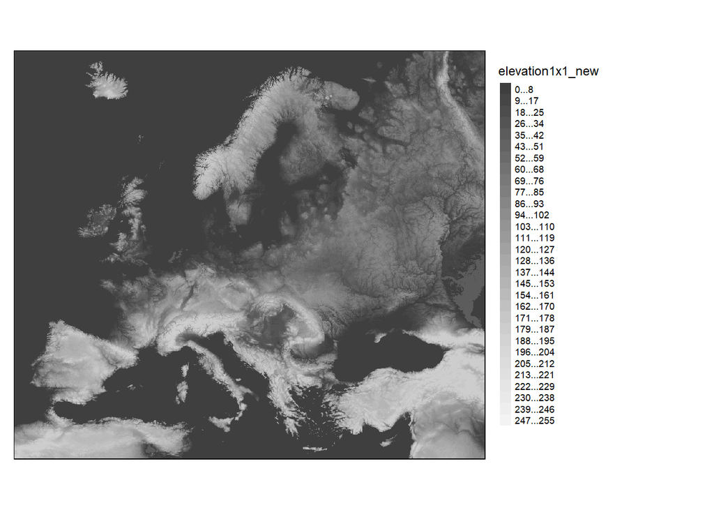

```r
# load raster file for europe
europe_raster <- raster("elevation1x1_new.tif")

#using tmap (explained later)

tm_shape(europe_raster)+
  tm_raster(style= "cont", palette=get_brewer_pal("-Greys", plot=FALSE)) +
  tm_layout(legend.outside = TRUE)
```

### Spatial data cubes

- Traditionally,spatial vector and raster data models refer to a unique set of locations
  - For example, each feature in a polygon dataset and each cell in a raster dataset refer to one specific area
  - But we need to store and operate on more complex data structures
  - Sometimes we have many attributes, often for several moments in time.

For example, consider a polygon data with many attributes representing land-use types for several years. How would we create a useful data object? * One approach: create a separate column for each variable in each year. * Second approach: have one column representing the year and one column for each attribute (requires multiplying each geometry as many times as we have time stamps) * Third approach: involves separating geometries from attributes, and where attributes for each moment are stored independently. -this is how we make spatial vector data cubes

*Examples of spatial data cubes: time-series of climate measurements for several stations, demographic data on a country level gathered for many years, or satellite images over some period of time

#### Example

see [link](https://coastwatch.gitbook.io/satellite-course/tutorials/r-tutorial/1.-how-to-work-with-satellite-data-in-r) for example tutorial (if we have time, work through this tutorial with a partner)

### Coordinate reference systems (CRS)

See this great [link](https://www.nceas.ucsb.edu/sites/default/files/2020-04/OverviewCoordinateReferenceSystems.pdf)

## References

[tmap: elegant and effective thematic maps in R](https://r-tmap.github.io/tmap-book/geodata.html)

[Geocomputation with R](https://geocompr.robinlovelace.net/spatial-class.html)

[Netcdf files](https://thiagodossantos.com/post/2-raster_basic_operations/)